# PROJECT 2: SUPERVISED LEARNING: FRAUD DETECTION

#### 5.3.3.3 Elastic Net

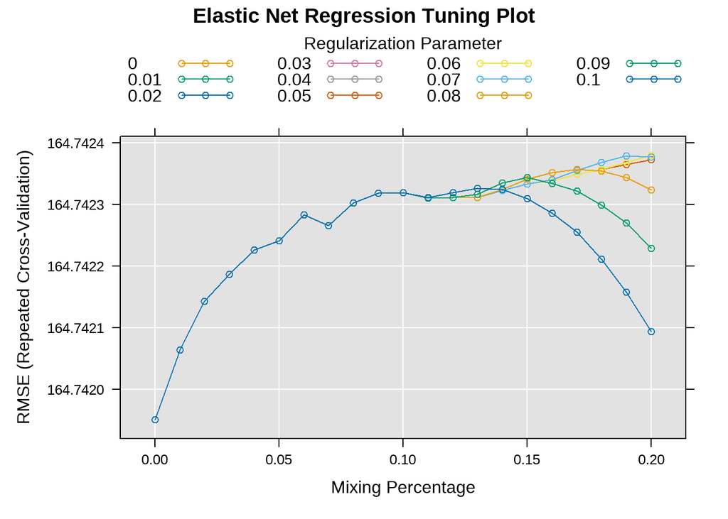

```r
# the grid for alpha and lambda
elastic_grid = expand.grid(alpha = seq(0, .2, 0.01), lambda = seq(0, .1, 0.01))

set.seed(123)
# train
glmnet_tune   <- train(model2, data = sampled_train_set_class,
                    method='glmnet',
                    preProc=c('scale','center'),
                    tuneGrid = elastic_grid,
                    trControl=ctrl)
plot(glmnet_tune , main = "Elastic Net Regression Tuning Plot")
```

```r
glmnet_tune $bestTune
```

```
##    alpha lambda
## 11     0    0.1
```

In summary, the Elastic Net regression tuning plot showcases the interplay between the mixing percentage (alpha) and the Root Mean Square Error (RMSE), with multiple lines representing different values of the regularization parameter (lambda). The selected combination of alpha = 0 and lambda = 0.1 indicates a preference for Ridge regression (L2 regularization) with a moderate level of regularization strength. This configuration strikes a balance between feature selection and coefficient shrinkage, addressing multicollinearity while controlling model complexity.

```r
test_results$glmnet <- predict(glmnet_tune , sampled_test_set_class)

postResample(pred = test_results$glmnet,  obs = test_results$Amount)
```

```
##        RMSE    Rsquared         MAE
## 92.54207504  0.00274608 59.77173689
```

```r
#       RMSE    Rsquared         MAE
#92.54207504  0.00274608 59.77173689
```

## 5.4 Machine Lerning Tools for Regression

### 5.4.1 K-Nearest-Neighbours (KNN)

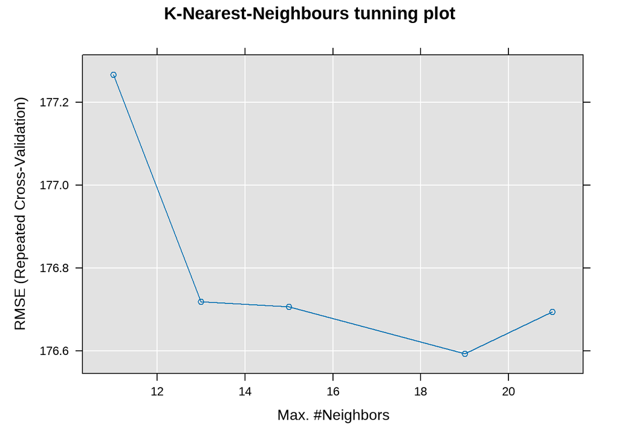

```r
set.seed(123)
knn_tune <- train(model2,
                  data = sampled_train_set_class,
                  method = "kknn",
                  preProc=c('scale','center'),
                  tuneGrid = data.frame(kmax=c(11,13,15,19,21),distance=2,kernel='optimal'),
                  trControl = ctrl)
plot(knn_tune, main = "K-Nearest-Neighbours tunning plot")
```

```r
test_results$knn <- predict(knn_tune, sampled_test_set_class)

postResample(pred = test_results$knn,  obs = test_results$Amount)
```

```
##         RMSE     Rsquared          MAE
## 1.094853e+02 9.289276e-05 6.755342e+01
```

These metrics provide insights into the performance of the KNN regression model. The RMSE reflects the average magnitude of prediction errors, with a higher value indicating a larger average error. The R-squared value, close to zero in this case, suggests that only a minimal proportion of variance in the response variable is explained by the model. The MAE represents the average absolute differences between predicted and observed values, and a lower MAE is desirable.

### 5.4.2 Random Forest

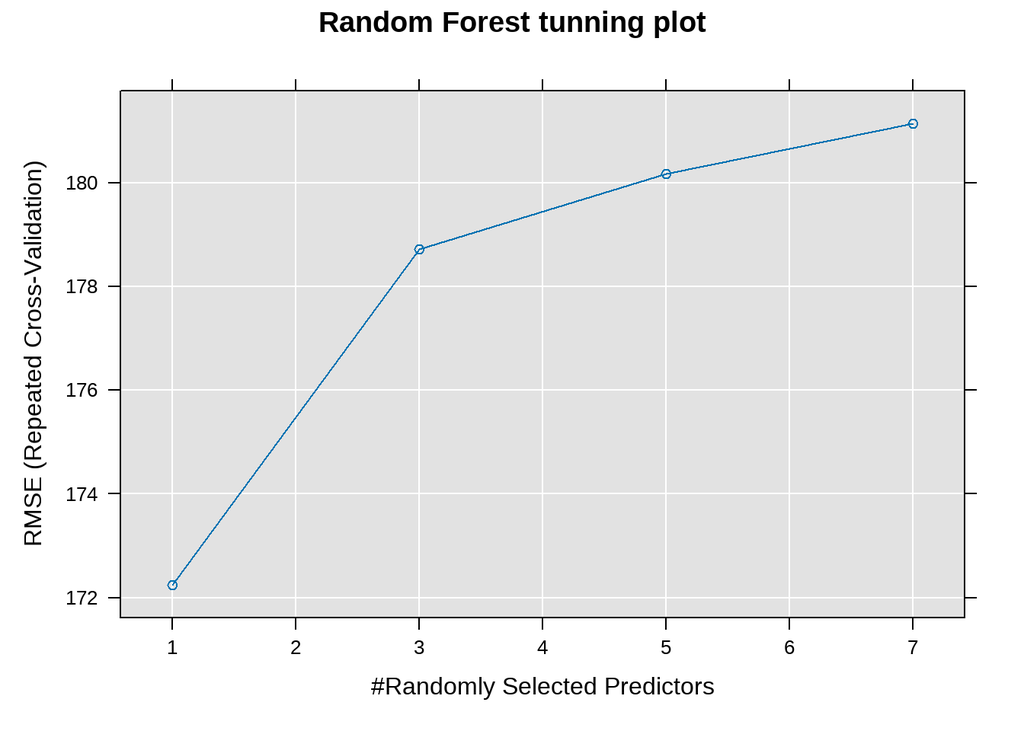

```r
set.seed(123)

rf_tune <- train(model2,
                 data = sampled_train_set_class,
                 method = "rf",
                 preProc=c('scale','center'),
                 trControl = ctrl,
                 ntree = 100,
                 tuneGrid = data.frame(mtry=c(1,3,5,7)),
                 importance = TRUE)
plot(rf_tune, main = "Random Forest tunning plot")
```

```r
test_results$rf <- predict(rf_tune, sampled_test_set_class)

postResample(pred = test_results$rf,  obs = test_results$Amount)
```

```
##         RMSE     Rsquared          MAE
## 1.009237e+02 8.608316e-04 6.241321e+01
```

The RMSE reflects the average magnitude of prediction errors, with a higher value indicating a larger average error. The R-squared value, while close to zero in this case, suggests that only a minimal proportion of variance in the response variable is explained by the model. The MAE represents the average absolute differences between predicted and observed values, and a lower MAE is desirable.

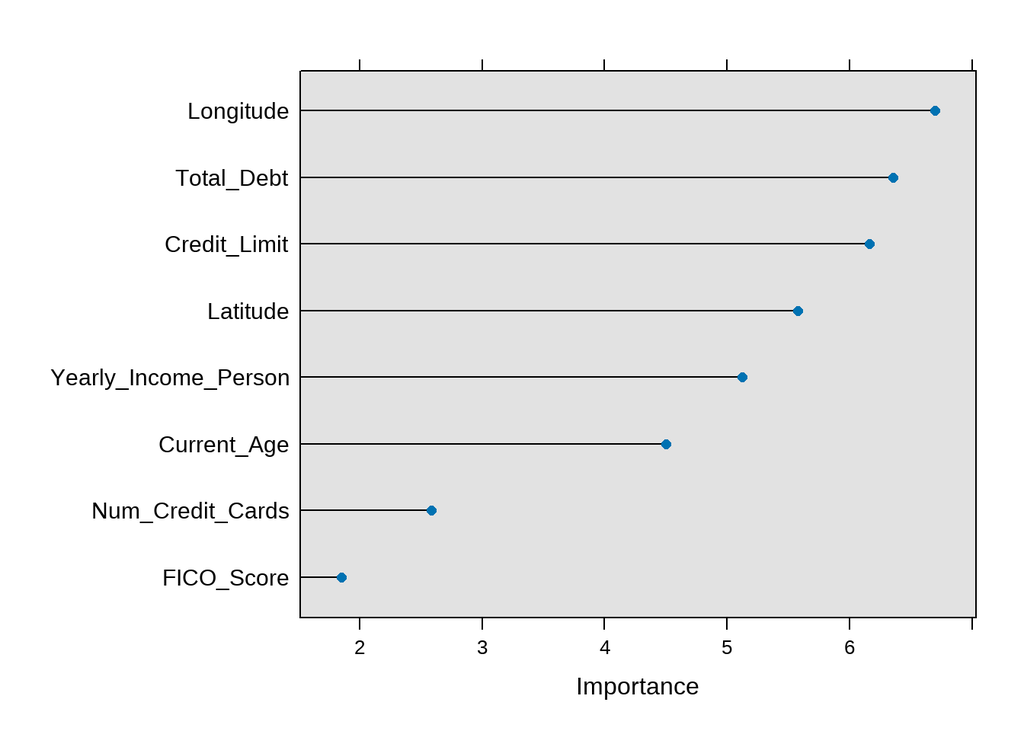

```r
plot(varImp(rf_tune, scale = F), scales = list(y = list(cex = .95)))
```

We can see which variables are more important

### 5.4.3 Ensemble

```r
apply(test_results[-1], 2, function(x) mean(abs(x - test_results$Amount)))
```

```
##       lm      lm2      frw       bw      seq    ridge    lasso   glmnet
## 59.97898 59.77059 59.76935 59.76935 59.76935 59.76260 59.98954 59.77174
##      knn       rf
## 67.55342 62.41321
```

```r
# Combination
test_results$comb = (test_results$ridge + test_results$seq + test_results$frw)/3

postResample(pred = test_results$comb,  obs = test_results$Amount)
```

```
##         RMSE     Rsquared          MAE
## 92.520719852  0.002704692 59.758728356
```

It is not a very good model, but it is better than the previous ones

## 5.5 Final predictions

```r
yhat = exp(test_results$comb)

head(yhat)
```

```
## [1] 2.601437e+35 2.195432e+34 1.909296e+35 9.312191e+34 7.167380e+28
## [6] 3.682434e+34
```

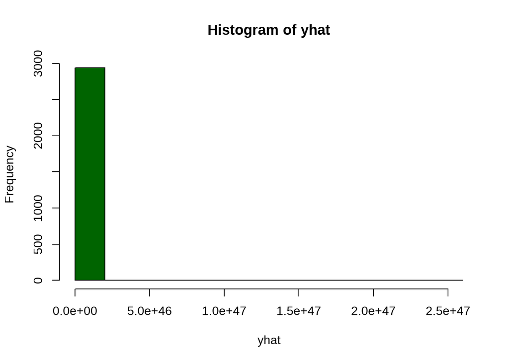

```r
hist(yhat, col="darkgreen")
```

## 5.6 Prediction Intervals

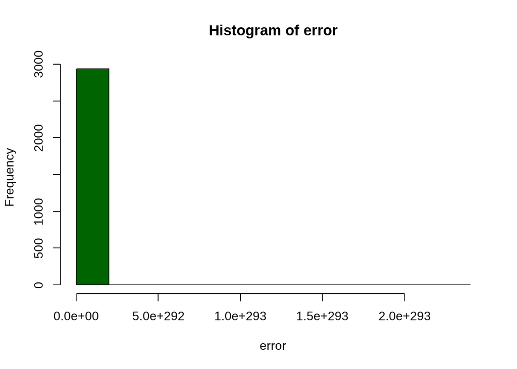

```r
y = exp(test_results$Amount)
error = y-yhat
hist(error, col="darkgreen")
```

```r
noise = error[1:200]
```

Prediction intervals: let’s fix a 90% confidence

```r
lwr = yhat[201:length(yhat)] + quantile(noise,0.05, na.rm=T) #5%, lower part of the error.
upr = yhat[201:length(yhat)] + quantile(noise,0.95, na.rm=T)
```

Next, we must aggregate the predictions by adding the quantiles. For the 5% quantile, the summation is akin to subtraction as the resulting number tends to be negative. We compute the quantiles using a segment of the testing set and subsequently apply these intervals to the remaining portion, constituting the final testing set.

Assessing the performance involves utilizing the last prices in the predicted values (yhat):

```r
predictions = data.frame(real=y[201:length(y)], fit=yhat[201:length(yhat)], lwr=lwr, upr=upr)

predictions = predictions %>% mutate(out=factor(if_else(real<lwr | real>upr,1,0)))

mean(predictions$out==1)
```

```
## [1] 0.0940576
```

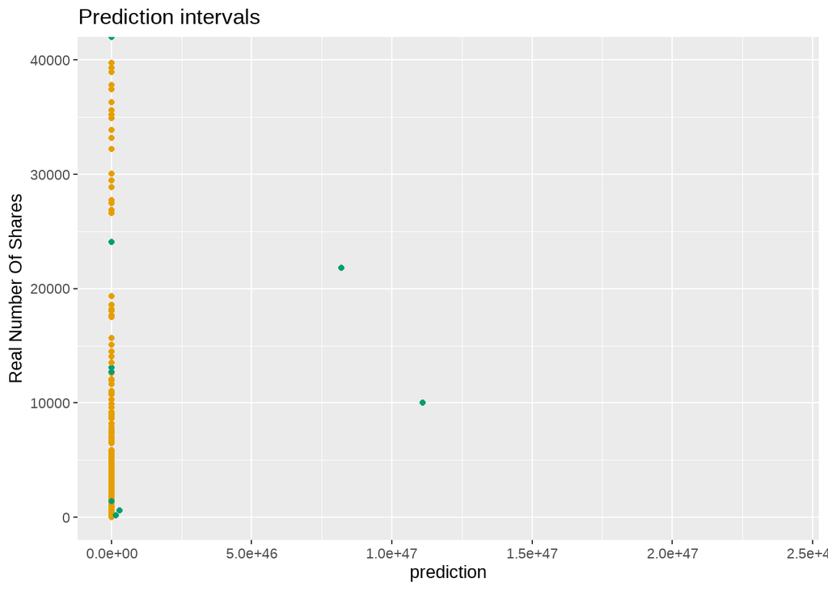

```r
ggplot(predictions, aes(x=fit, y=real))+
  geom_point(aes(color=out)) + theme(legend.position="none") + ylim(0,  40000)+
  geom_ribbon(data=predictions,aes(ymin=lwr,ymax=upr),alpha=0.3) +
  labs(title = "Prediction intervals", x = "prediction",y="Real Number Of Shares")
```

We get really bad results

### 5.6.1 Conclusion about Regression

In conclusion, the regression project aimed to predict transaction amounts utilizing various regression techniques, with a particular focus on ensemble methods. However, the results obtained for predicting transaction amounts using the ensemble of models have been notably suboptimal. Despite employing a combination of regression algorithms, including random forest and others, the predictive performance, as indicated by metrics such as mean absolute error (MAE), has fallen short of expectations.

Several potential reasons could contribute to the challenges in predicting transaction amounts accurately:

Data Quality and Feature Engineering: The quality and relevance of the features used in the models play a crucial role. If the dataset lacks informative features or if feature engineering is not performed effectively, models may struggle to capture the underlying patterns in the data.

Model Complexity: Ensemble methods, while powerful, can be sensitive to overfitting if model complexity is not appropriately managed. It’s essential to strike a balance between model complexity and generalization to new data.

Hyperparameter Tuning: The performance of ensemble models heavily depends on hyperparameter settings. Inadequate tuning or improper configuration of hyperparameters may hinder the models’ ability to learn and generalize from the data.

Inherent Complexity of Transaction Data: The nature of transaction data can be inherently complex, with various factors contributing to the transaction amounts. If the underlying patterns are intricate or subject to rapid changes, models may struggle to capture these dynamics accurately.

Moving forward, it’s recommended to revisit the data preprocessing steps, consider additional feature engineering techniques, and explore alternative ensemble methods or machine learning algorithms. Fine-tuning hyperparameters and thoroughly evaluating model performance with cross-validation can also contribute to enhancing predictive accuracy. Additionally, seeking domain expertise to gain a deeper understanding of transactional dynamics may provide valuable insights for refining the regression models.